# AAPL Project

```python
import pandas as pd
import numpy as np
import matplotlib.pyplot as plt
import seaborn as sns

# Load data from local CSV (no API rate limits)
df = pd.read_csv("AAPL_2020_2024.csv")

# Keep necessary columns
df = df[["Date", "Close"]].copy()
df["Date"] = pd.to_datetime(df["Date"])
df["Close"] = df["Close"].astype(float)

# Display data
print(df.head())
print("Initial data shape:", df.shape)
```

```
        Date       Close
0 2020-01-01  301.293428
1 2020-01-02  301.316900
2 2020-01-03  302.912277
3 2020-01-06  306.258336
4 2020-01-07  306.090030
Initial data shape: (1305, 2)
```

Featured Engineering - Create Lag, RSI, SMA, EMA, and Target

```python
# Return
df["Return"] = df["Close"].pct_change()

# Lagged closing prices
df["Lag_1"] = df["Close"].shift(1)
df["Lag_2"] = df["Close"].shift(2)
df["Lag_3"] = df["Close"].shift(3)

# RSI function definition
def compute_rsi(prices, window=14):
    delta = prices.diff()
    gain = delta.clip(lower=0)
    loss = -delta.clip(upper=0)

    avg_gain = gain.rolling(window=window, min_periods=1).mean()
    avg_loss = loss.rolling(window=window, min_periods=1).mean()

    rs = avg_gain / (avg_loss + 1e-10) # Avoid division by zero
    rsi = 100 - (100 / (1 + rs))
    return rsi

df["RSI_14"] = compute_rsi(df["Close"])

# SMA and EMA (simple moving averages and exponential moving average)
df["SMA_5"] = df["Close"].rolling(window=5, min_periods=1).mean()
df["SMA_10"] = df["Close"].rolling(window=10, min_periods=1).mean()
df["EMA_5"] = df["Close"].ewm(span=5, adjust=False).mean()

# Target variable (up or down tomorrow)
df["Target"] = (df["Return"].shift(-1) > 0).astype(int)

# Explicitly drop rows with NaNs
df.dropna(inplace=True)

# Inspect the data after feature engineering
print(df.head())
print("Shape after feature engineering:", df.shape)
```

```
        Date       Close    Return       Lag_1       Lag_2       Lag_3  \
3 2020-01-06  306.258336  0.011046  302.912277  301.316900  301.293428
4 2020-01-07  306.090030 -0.000550  306.258336  302.912277  301.316900
5 2020-01-08  305.921756 -0.000550  306.090030  306.258336  302.912277
6 2020-01-09  309.380181  0.011305  305.921756  306.090030  306.258336
7 2020-01-10  311.215051  0.005931  309.380181  305.921756  306.090030

       RSI_14       SMA_5      SMA_10       EMA_5  Target
3  100.000000  302.945235  302.945235  303.311619       0
4   96.721221  303.574194  303.574194  304.237756       0
5   93.651205  304.499860  303.965454  304.799089       1
6   96.157717  306.112516  304.738987  306.326120       1
7   96.823147  307.773071  305.548495  307.955764       0
Shape after feature engineering: (1302, 11)
```

Exploratory Data Analysis

[figure not shown]

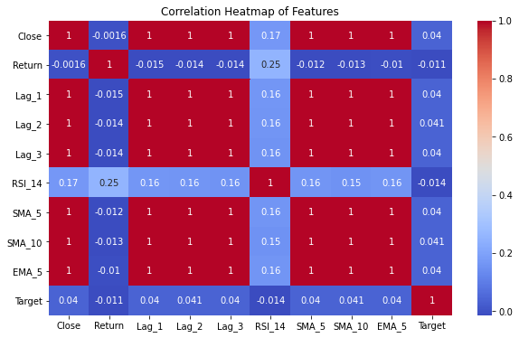

```python
# Distribution plot
df["Target"].value_counts().plot(kind='bar', color=['blue', 'orange'])
plt.title("Distribution of Target Variable (1 = Up, 0 = Down)")
plt.xlabel("Target")
plt.ylabel("Count")
plt.xticks(ticks=[0, 1], labels=['Down (0)', 'Up (1)'], rotation=0)
plt.grid(axis='y', alpha=0.3)
plt.show()

# Correlation heatmap (without Date)
plt.figure(figsize=(10, 6))
sns.heatmap(df.drop(columns=["Date"]).corr(), annot=True, cmap='coolwarm')
plt.title('Correlation Heatmap of Features')
plt.show()
```

**Visual of Plot Close and RSI**

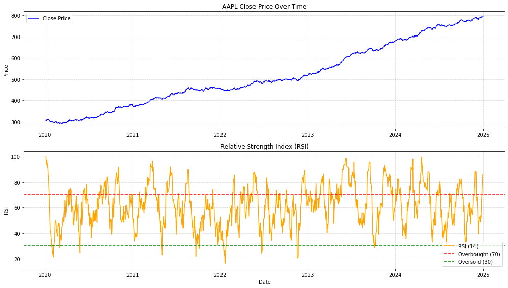

```python
# Explicitly cast Date to numpy array
dates = df["Date"].values
close_prices = df["Close"].values
rsi_values = df["RSI_14"].values

# Plot Close Price and RSI
plt.figure(figsize=(14, 8))

# Close Price Plot
plt.subplot(2, 1, 1)
plt.plot(dates, close_prices, color='blue', label='Close Price')
plt.title('AAPL Close Price Over Time')
plt.ylabel('Price')
plt.grid(True, linestyle='--', alpha=0.5)
plt.legend()

# RSI Plot
plt.subplot(2, 1, 2)
plt.plot(dates, rsi_values, color='orange', label='RSI (14)')
plt.axhline(70, color='red', linestyle='--', label='Overbought (70)')
plt.axhline(30, color='green', linestyle='--', label='Oversold (30)')
plt.title('Relative Strength Index (RSI)')
plt.xlabel('Date')
plt.ylabel('RSI')
plt.grid(True, linestyle='--', alpha=0.5)
plt.legend()

plt.tight_layout()
plt.show()
```

Observation: This visualization gives a clear view of how AAPL's stock price moves over time and how momentum shifts. When RSI rises above 70, it often coincides with price peaks, suggesting potential overbought conditions. When RSI drops below 30, it often aligns with price dips, signaling possible rebounds. This dual chart helps investors time entries and exits more strategically.

Predictive Modeling (Machine Learning)

```python
from sklearn.model_selection import train_test_split

# Define features (X) and target (y)
X = df[["Lag_1", "Lag_2", "Lag_3", "RSI_14", "SMA_5", "SMA_10", "EMA_5"]]
y = df["Target"]

# Split data into training and testing sets (80%-20%)
X_train, X_test, y_train, y_test = train_test_split(X, y, test_size=0.2, shuffle=False)

# Check shapes
print("Training shape:", X_train.shape, y_train.shape)
print("Testing shape:", X_test.shape, y_test.shape)
```

```
Training shape: (1041, 7) (1041,)
Testing shape: (261, 7) (261,)
```

```python
from sklearn.linear_model import LogisticRegression
from sklearn.ensemble import RandomForestClassifier

# Initialize models
logreg = LogisticRegression(random_state=42, max_iter=1000)
rf = RandomForestClassifier(random_state=42, n_estimators=100)

# Train models
logreg.fit(X_train, y_train)
rf.fit(X_train, y_train)
```

```
RandomForestClassifier(random_state=42)
```

```python
from sklearn.metrics import classification_report, confusion_matrix

# Logistic Regression evaluation
y_pred_logreg = logreg.predict(X_test)
print("Logistic Regression Classification Report:")
print(classification_report(y_test, y_pred_logreg))
print("Confusion Matrix:\n", confusion_matrix(y_test, y_pred_logreg))

# Random Forest evaluation
y_pred_rf = rf.predict(X_test)
print("Random Forest Classification Report:")
print(classification_report(y_test, y_pred_rf))
print("Confusion Matrix:\n", confusion_matrix(y_test, y_pred_rf))
```

```
Logistic Regression Classification Report:
              precision    recall  f1-score   support

           0       0.00      0.00      0.00       104
           1       0.60      1.00      0.75       157

    accuracy                           0.60       261
   macro avg       0.30      0.50      0.38       261
weighted avg       0.36      0.60      0.45       261

Confusion Matrix:
 [[  0 104]
 [  0 157]]
Random Forest Classification Report:
              precision    recall  f1-score   support

           0       0.41      0.62      0.49       104
           1       0.62      0.41      0.50       157

    accuracy                           0.49       261
   macro avg       0.51      0.51      0.49       261
weighted avg       0.54      0.49      0.49       261

Confusion Matrix:
 [[64 40]
 [92 65]]
```

[output not shown]

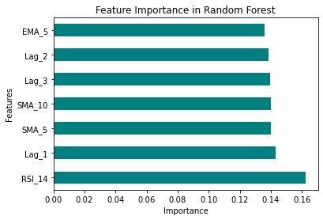

```python
import matplotlib.pyplot as plt

# Feature importance plot
feat_importances = pd.Series(rf.feature_importances_, index=X.columns)
feat_importances.nlargest(7).plot(kind='barh', color='teal')
plt.title("Feature Importance in Random Forest")
plt.xlabel("Importance")
plt.ylabel("Features")
plt.show()
```

**Observation:**

Now, I’ll evaluate the accuracy and predictive power of these models to identify which model better aligns with my project's goal of predicting stock market movements.

```python
df.columns = df.columns.str.strip()  # removes any leading/trailing whitespace
print(df.columns)                    # confirm you have 'Date', 'Close', etc.
print(df.dtypes)
print(df.head())
```

[output not shown]

```python
print(df.columns)
print(type(df["Date"]))
print(type(df["Close"]))
print(df[["Date", "Close"]].head())
```

[output not shown]

```python
df["Date"] = pd.to_datetime(df["Date"], errors="coerce")
df["Close"] = pd.to_numeric(df["Close"], errors="coerce")

# Drop any rows where date or close is invalid
df = df.dropna(subset=["Date", "Close"])

# Reset index just in case
df = df.reset_index(drop=True)
```

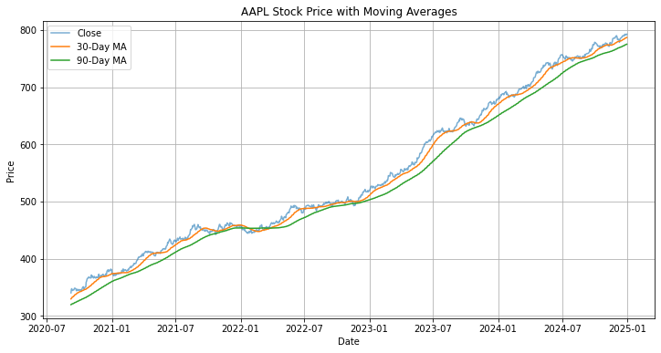

```python
plt.figure(figsize=(12, 6))
plt.plot(df["Date"].values, df["Close"].values, label="Close", alpha=0.6)
plt.plot(df["Date"].values, df["MA30"].values, label="30-Day MA")
plt.plot(df["Date"].values, df["MA90"].values, label="90-Day MA")
plt.title("AAPL Stock Price with Moving Averages")
plt.xlabel("Date")
plt.ylabel("Price")
plt.legend()
plt.grid(True)
plt.show()
```

**Observation**

The chart displays Apple Inc.'s (AAPL) historical stock performance from 2020 to 2024, showcasing three key lines: the daily closing price, a 30-day moving average (orange), and a 90-day moving average (green). The closing price represents the actual market value of AAPL stock at the end of each trading day. Over the entire period, there is a clear upward trend in all three lines, indicating that the stock price has steadily increased over time. The moving averages further confirm this pattern by smoothing out short-term fluctuations and highlighting the long-term growth trajectory. This consistent rise suggests strong historical performance and may reflect positive investor sentiment, earnings growth, or broader market trends benefiting Apple’s valuation.

```python
df["Target"] = (df["Close"].shift(-1) > df["Close"]).astype(int)
```

```python
# Make sure 'Date' is in datetime format
df["Date"] = pd.to_datetime(df["Date"])

# Extract features
df["Year"] = df["Date"].dt.year
df["Month"] = df["Date"].dt.month
df["Day"] = df["Date"].dt.day
df["DayOfWeek"] = df["Date"].dt.dayofweek  # 0 = Monday, 6 = Sunday
df["WeekOfYear"] = df["Date"].dt.isocalendar().week

# Optional: Encode whether it's start or end of the month
df["IsMonthStart"] = df["Date"].dt.is_month_start.astype(int)
df["IsMonthEnd"] = df["Date"].dt.is_month_end.astype(int)

df.head()
```

[output not shown]

```python
# Volatility: 30-day rolling std dev of Close price
df["Volatility_30"] = df["Close"].rolling(window=30).std()
```

```python
from sklearn.model_selection import train_test_split

# Define features and target
features = ["MA30", "MA90", "Volatility_30", "Year", "Month", "Day", "DayOfWeek", "WeekOfYear"]
target = "Close"

# Drop rows with missing values (from rolling calculations)
df_model = df.dropna(subset=features + [target])

X = df_model[features]
y = df_model[target]

# Split into training and testing data (80/20 split)
X_train, X_test, y_train, y_test = train_test_split(X, y, test_size=0.2, shuffle=False)
```

```python
from sklearn.linear_model import LinearRegression
from sklearn.metrics import mean_squared_error, r2_score

# Train the model
model = LinearRegression()
model.fit(X_train, y_train)

# Predict
y_pred = model.predict(X_test)

# Evaluate
mse = mean_squared_error(y_test, y_pred)
r2 = r2_score(y_test, y_pred)

print(f"Mean Squared Error: {mse:.2f}")
print(f"R-squared: {r2:.4f}")
```

```
Mean Squared Error: 25.29
R-squared: 0.9644
```

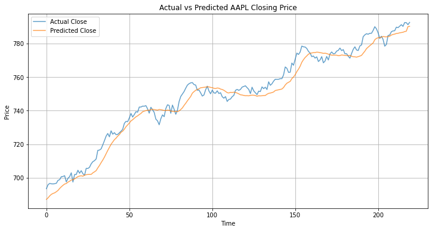

```python
import matplotlib.pyplot as plt

# Plot real vs predicted prices
plt.figure(figsize=(12, 6))
plt.plot(y_test.values, label="Actual Close", alpha=0.7)
plt.plot(y_pred, label="Predicted Close", alpha=0.7)
plt.title("Actual vs Predicted AAPL Closing Price")
plt.xlabel("Time")
plt.ylabel("Price")
plt.legend()
plt.grid(True)
plt.show()
```

**Observation**

The plotted comparison between actual closing prices (blue line) and predicted prices (orange line) reveals a strong correlation in overall trend direction:

✅ The model effectively captures the upward momentum in AAPL stock over time, particularly in smoother, stable growth periods.

📉 Short-term fluctuations, sudden dips, or spikes are less precisely predicted, which is expected from a simple linear regression model without advanced time-series techniques.

📊 The prediction line closely follows the actual trend, with some lag in capturing turning points—suggesting the model generalizes the trend but struggles with volatility.

Conclusion: The model provides a solid first-step forecast and demonstrates that even basic regression models—when paired with feature engineering (like moving averages)—can generate meaningful insights into financial time series behavior.

```python
predicted = model.predict(X_test)
```

```python
from sklearn.metrics import mean_squared_error, r2_score
print("MSE:", mean_squared_error(y_test, predicted))
print("R² Score:", r2_score(y_test, predicted))
```

```
MSE: 25.291780996599847
R² Score: 0.9644280511345472
```

**Interpretation**

MSE tells us the average squared difference between predicted and actual values — the lower, the better. R² (coefficient of determination) tells us how much variance in the target variable is explained by the model. Closer to 1 = better fit. Values around 0.9+ are excellent for financial time series.

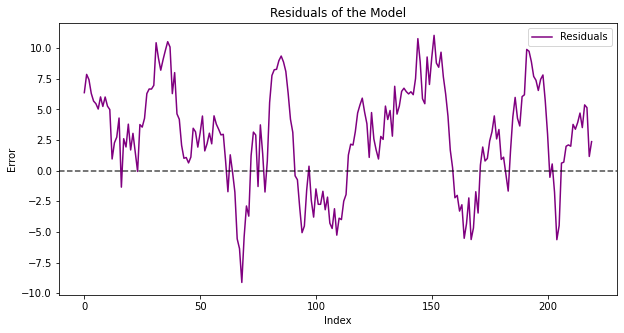

```python
residuals = y_test - predicted

plt.figure(figsize=(10,5))
plt.plot(residuals.values, label='Residuals', color='purple')
plt.axhline(0, linestyle='--', color='black', alpha=0.7)
plt.title("Residuals of the Model")
plt.xlabel("Index")
plt.ylabel("Error")
plt.legend()
plt.show()
```

**Observation**